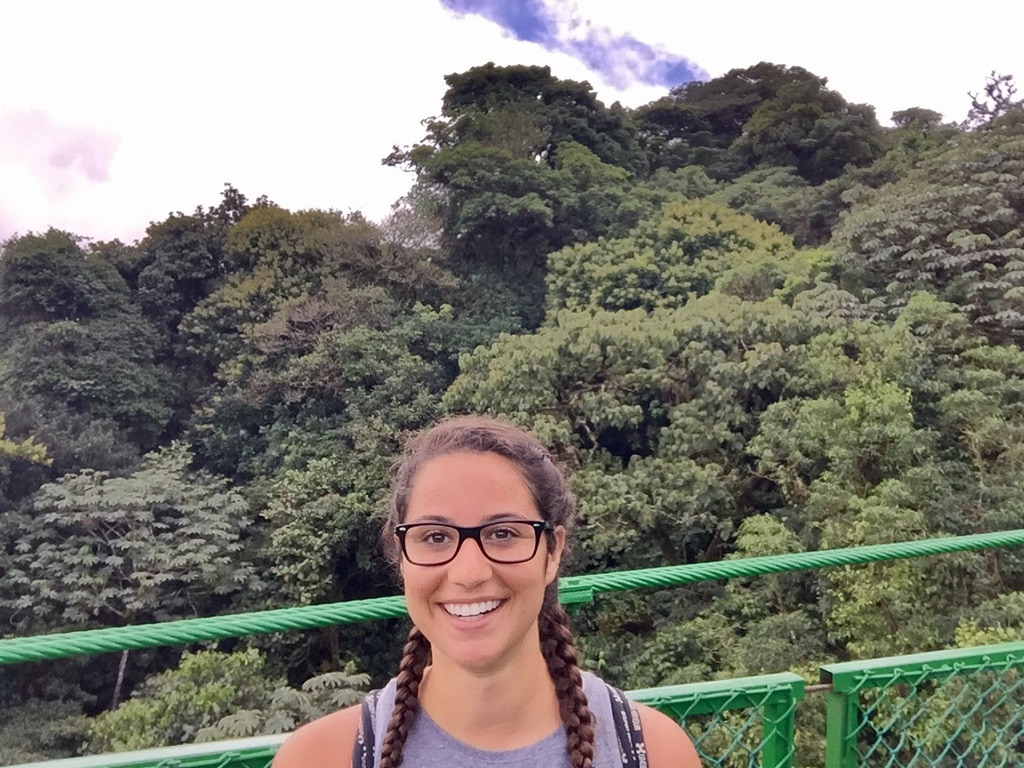

I’m currently a third-year PhD student in Biostatistics in the [Department of Biostatistics, Epidemiology, and Informatics](http://www.dbei.med.upenn.edu/) at the University of Pennsylvania. I am an active researcher in the [PennSIVE](https://www.med.upenn.edu/pennsive/) working group under the mentorship of [Russell [Taki] Shinohara](https://www.med.upenn.edu/apps/faculty/index.php/g275/p8574254). Primarily, my research interests lie in the development of statistical methods for analyzing neuroimaging data sets with the goal of understanding disease processes in the brain. Currently, my projects involve the analysis of multi-sequence structural MRI for the study of multiple sclerosis. I collaborate regularly with experts in bioengineering, radiology, and neurology.

I earned my M.S. in Biostatistics from University of Pennsylvania in 2017. My thesis proposed a novel machine learning algorithm, MIMoSA, to automatically detect T2 hyperintense white matter lesions in multiple sclerosis. Before coming to Penn, I obtained my undergraduate degree in Biology and Statistics (Honors) from University of Connecticut.